# 时间序列和因果关系

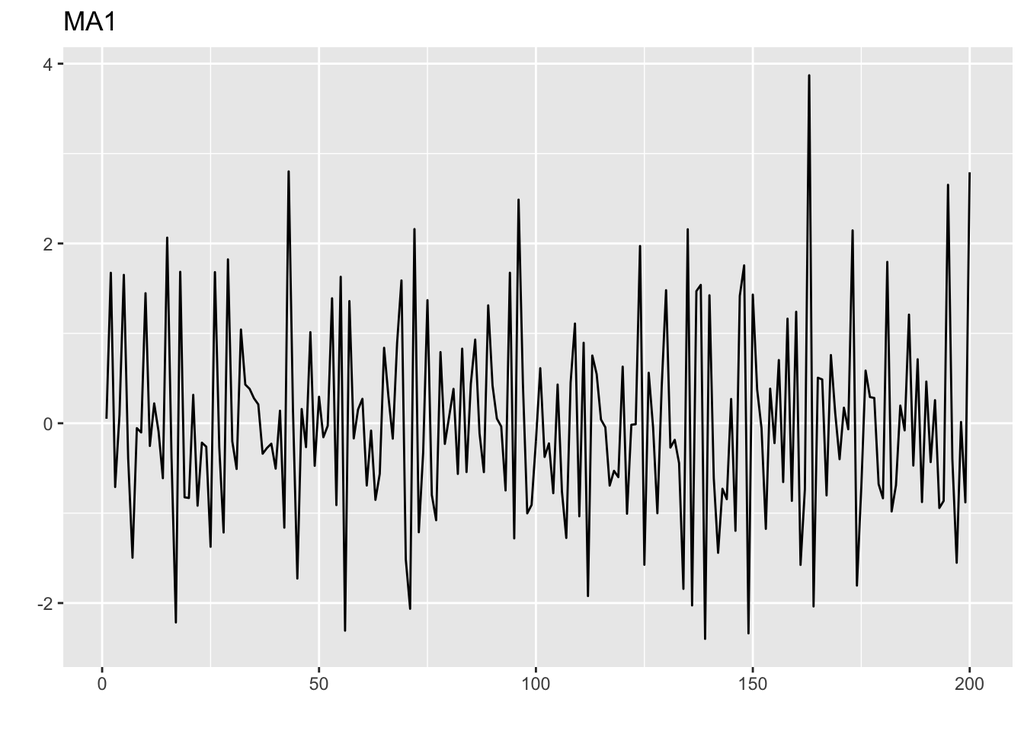

```r
## 一阶延迟具有显著的相关性
set.seed(123)
ma1 <- arima.sim(list(order = c(0, 0, 1), ma = -0.5), n = 200)
autoplot(ma1, main = "MA1")
```

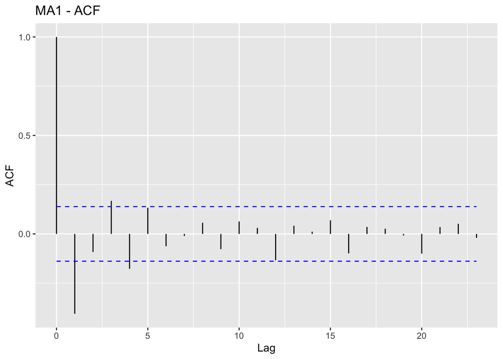

```r
autoplot(acf(ma1, plot = F), main = "MA1 - ACF")
```

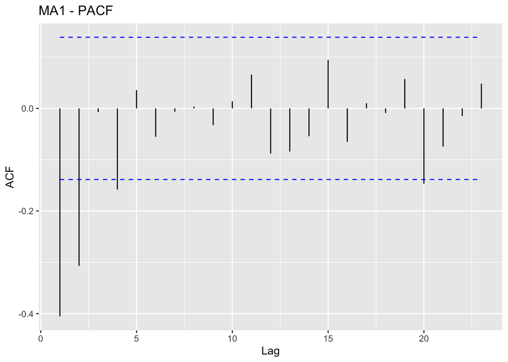

```r
autoplot(pacf(ma1, plot = F), main = "MA1 - PACF")
```

## 1.2 格兰杰因果关系

如果有两组时间序列数据x和y，格兰杰因果关系模型负责确定一个序列是否会影响另 一个序列中的变化。它的做法是使用一个序列中的不同延迟序列为第二个序列中的变化建模。要 达成这个目的，需要建立两个模型以预测y，一个模型只使用y的前期数据(Ω)，另一个模型使 用y的前期数据和x(π)。

# 2 Application

## 2.1 数据准备

```r
climate <- read.csv("~/Library/Mobile Documents/com~apple~CloudDocs/02. Programm/01 R_lernen/00 Data/climate.csv",stringsAsFactors = F)
str(climate)
```

```
## 'data.frame':    95 obs. of  3 variables:
##  $ Year: int  1919 1920 1921 1922 1923 1924 1925 1926 1927 1928 ...
##  $ CO2 : int  806 932 803 845 970 963 975 983 1062 1065 ...
##  $ Temp: num  -0.272 -0.241 -0.187 -0.301 -0.272 -0.292 -0.214 -0.105 -0.208 -0.206 ...
```

```r
## 转换为时间序列结构，指定开始年份和结束年份
climate <- ts(climate[, 2:3], frequency = 1,
              start = 1919, end = 2013)
head(climate)
```

```
##      CO2   Temp
## [1,] 806 -0.272
## [2,] 932 -0.241
## [3,] 803 -0.187
## [4,] 845 -0.301
## [5,] 970 -0.272
## [6,] 963 -0.292
```

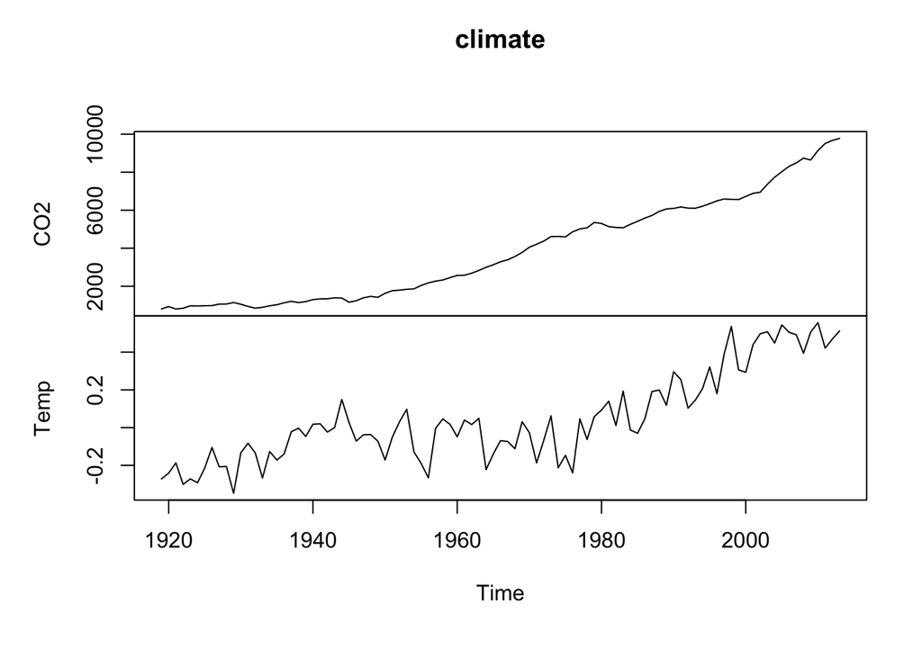

```r
library(forecast)
library(tseries)

## 绘制两个时间序列
plot(climate)
```

```r
## 二氧化碳排放水平确实在第二次世界大战后开始增长，温度的异常变化大 约发生在20世纪70年代中期，那时开始急剧升高。没有明显的异常值，不同时间的方差看上去也 6 是个固定值。通过标准的分析过程可以知道，两个序列是高度相关的
cor(climate)
```

```
##            CO2      Temp
## CO2  1.0000000 0.8404215
## Temp 0.8404215 1.0000000
```

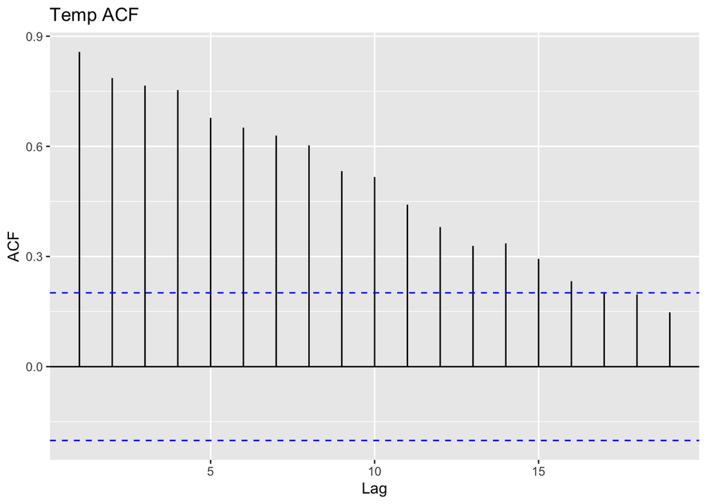

```r
## 绘制两个序列的ACF图和 PACF图
autoplot(acf(climate[, 2], plot = F), main="Temp ACF")
```

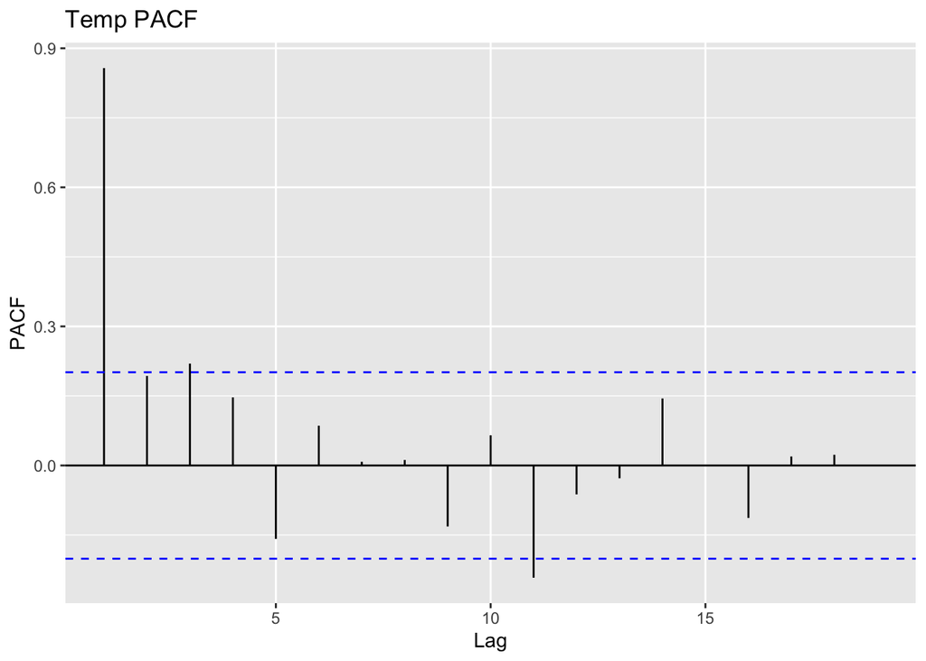

```r
autoplot(pacf(climate[, 2], plot = F), main="Temp PACF")
```

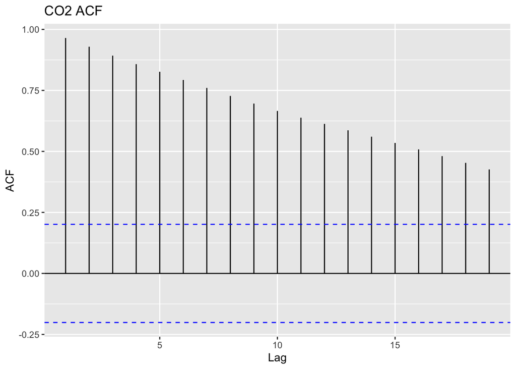

```r
autoplot(acf(climate[, 1], plot = F), main="CO2 ACF")
```

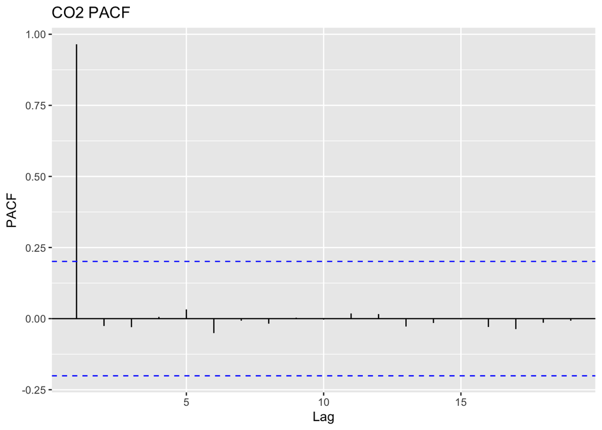

```r
autoplot(pacf(climate[, 1], plot = F), main = "CO2 PACF")
```

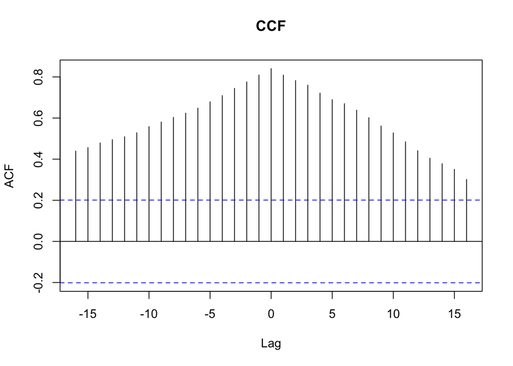

```r
## ACF模式是逐渐衰减的，PACF模式则是快速衰减的。可以假设这两个序列都是自回归的



## 检查交叉相关函数。请注意，在函数中，要把x放在y的前面:
## CCF图展示了温度和二氧化碳延迟序列之间的相关性。如果x变量的负延迟序列具有强相关 性，则x领先于y;如果x变量的正延迟序列具有强相关性，则x滞后于y。此处可以看到，二氧化 碳既是个领先变量，也是个滞后变量
ccf(climate[, 1], climate[, 2], main = "CCF")
```

```r
## 检验数据是否平稳。可以通过tseries包中提供的扩展迪基福勒检验实现这个操作
adf.test(climate[, 1])
```

```
##
##  Augmented Dickey-Fuller Test
##
## data:  climate[, 1]
## Dickey-Fuller = -1.1519, Lag order = 4, p-value = 0.9101
## alternative hypothesis: stationary
```

```r
adf.test(climate[, 2])
```

```
##
##  Augmented Dickey-Fuller Test
##
## data:  climate[, 2]
## Dickey-Fuller = -1.8106, Lag order = 4, p-value = 0.6546
## alternative hypothesis: stationary
```

## 2.2 模型构建

1. 第一，建立一个仅应用于温度数据的单变量预测 模型;
2. 第二，基于温度数据本身和二氧化碳排放量数据建立一个温度数据的回归模型;
3. 第三，使 用这个模型的输出揭示二氧化碳排放量和地表温度异常之间是否存在格兰杰因果关系。

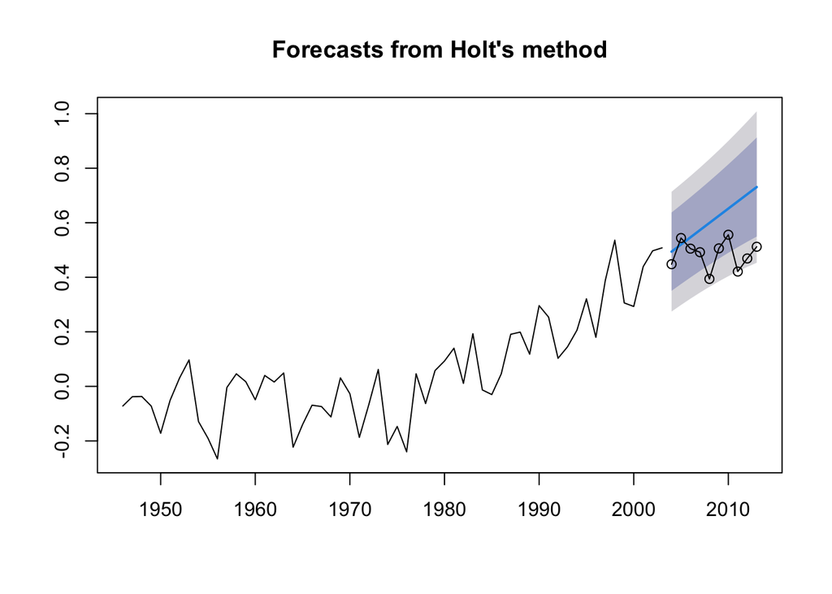

```r
## 测试集与训练集使用不同的时间序列
temp <- climate[, 2]
train <- window(temp, start = 1946, end = 2003)
test <- window(temp, start = 2004)

## 建立平滑模型，可以使用forecast包中的holt()函数
## 没有阻尼趋势的holt模型
fit.holt <- holt(train, h = 10, initial = "optimal")
# summary(fit.holt)
plot(forecast(fit.holt))
lines(test, type= "o")
```

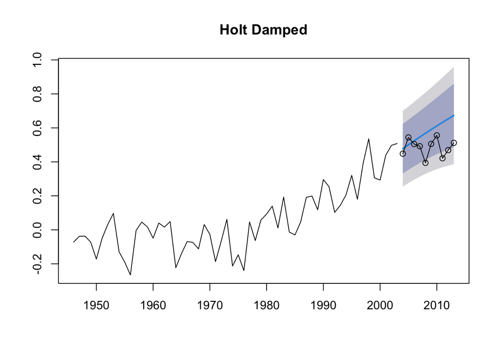

```r
## 有阻尼趋势的holt模型
fit.holtd <- holt(train, h = 10, initial = "optimal", damped = TRUE)
# summary(fit.holtd)
plot(forecast(fit.holtd), main ="Holt Damped")
lines(test, type = "o")
```

```r
## 建立一个ARIMA模型，使用forecast包中的auto.arima()函数
fit.arima <- auto.arima(train)
summary(fit.arima)
```

```
## Series: train
## ARIMA(0,1,1) with drift
##
## Coefficients:
##           ma1   drift
##       -0.6949  0.0094
## s.e.   0.1041  0.0047
##
## sigma^2 estimated as 0.01273:  log likelihood=44.18
## AIC=-82.37   AICc=-81.92   BIC=-76.24
##
## Training set error measures:
##                         ME      RMSE        MAE      MPE     MAPE     MASE
## Training set -0.0007038922 0.1098561 0.09017707 26.99009 153.2556 0.878048
##                   ACF1
## Training set 0.1282754
```

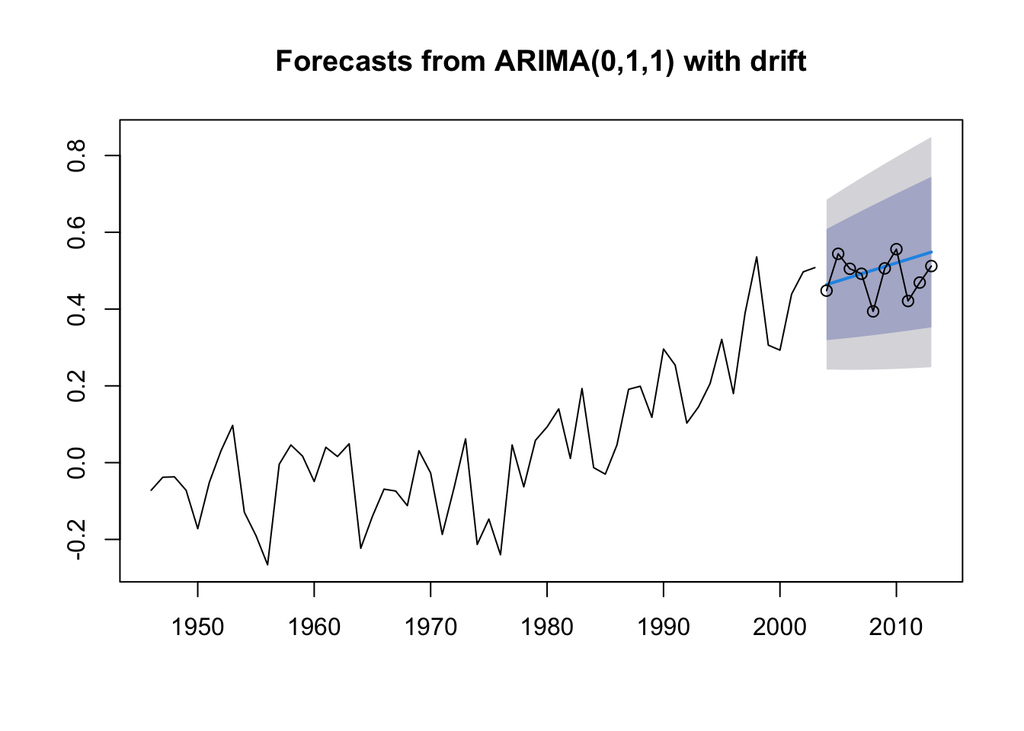

```r
## 函数选择的模型是MA = 1、I = 1，也就是带有漂移项(等价于截距) 的ARIMA(0, 1, 1)。和前面一样
plot(forecast(fit.arima, h = 10))
lines(test, type="o")
```

```r
## 为每种模型打分，找出具有最低误差，即平均绝对百分误差的模型
mapeHOLT <- sum(abs((test - fit.holt$mean)/test))/10
mapeHOLT
```

```
## [1] 0.2864105
```

```r
mapeHOLTD <- sum(abs((test - fit.holtd$mean)/test))/10
mapeHOLTD
```

```
## [1] 0.2211337
```

```r
mapeARIMA <- sum(abs((test - forecast(fit.arima, h = 10)$mean)/test))/10
mapeARIMA
```

```
## [1] 0.1034813
```

```r
## 通过统计检验和可视化证据，单变量预测模型的最好选择似乎是ARIMA模型
```

## 2.3 检查因果关系

### 2.3.1 线性回归

```r
fit.lm <- lm(Temp ~ CO2, data = climate)
summary(fit.lm)
```

```
##
## Call:
## lm(formula = Temp ~ CO2, data = climate)
##
## Residuals:
##      Min       1Q   Median       3Q      Max
## -0.36411 -0.08986  0.00011  0.09475  0.28763
##
## Coefficients:
##               Estimate Std. Error t value Pr(>|t|)
## (Intercept) -2.430e-01  2.357e-02  -10.31   <2e-16 ***
## CO2          7.548e-05  5.047e-06   14.96   <2e-16 ***
## ---
## Signif. codes:  0 '***' 0.001 '**' 0.01 '*' 0.05 '.' 0.1 ' ' 1
##
## Residual standard error: 0.1299 on 93 degrees of freedom
## Multiple R-squared:  0.7063, Adjusted R-squared:  0.7032
## F-statistic: 223.7 on 1 and 93 DF,  p-value: < 2.2e-16
```

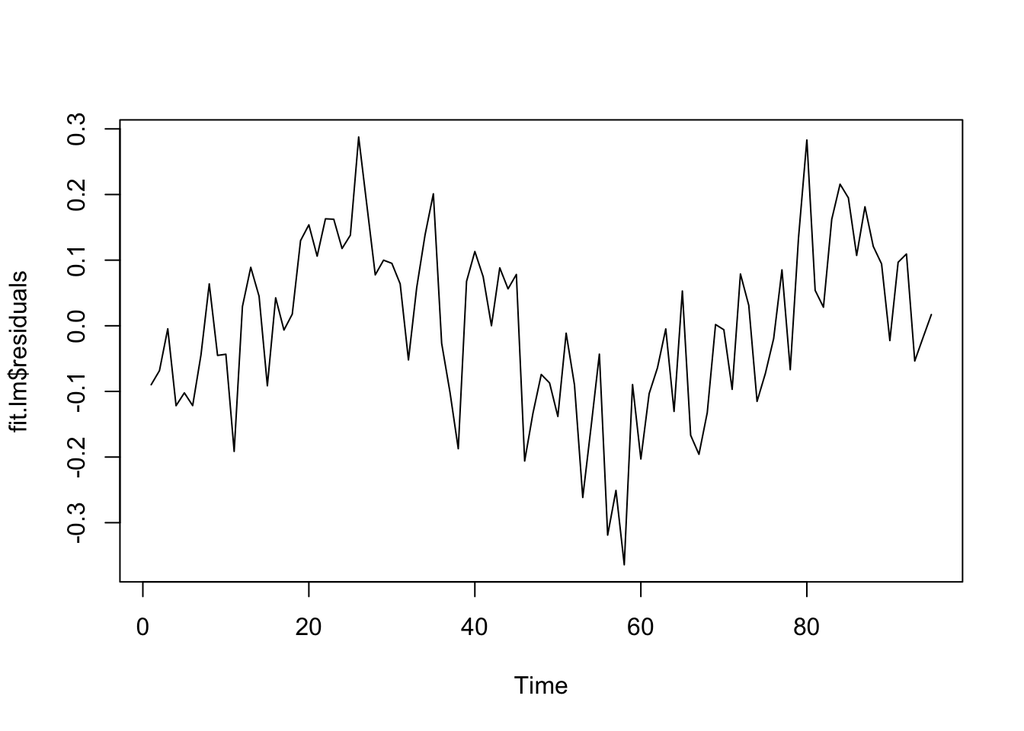

```r
## 残差的时间序列图
plot.ts(fit.lm$residuals)
```

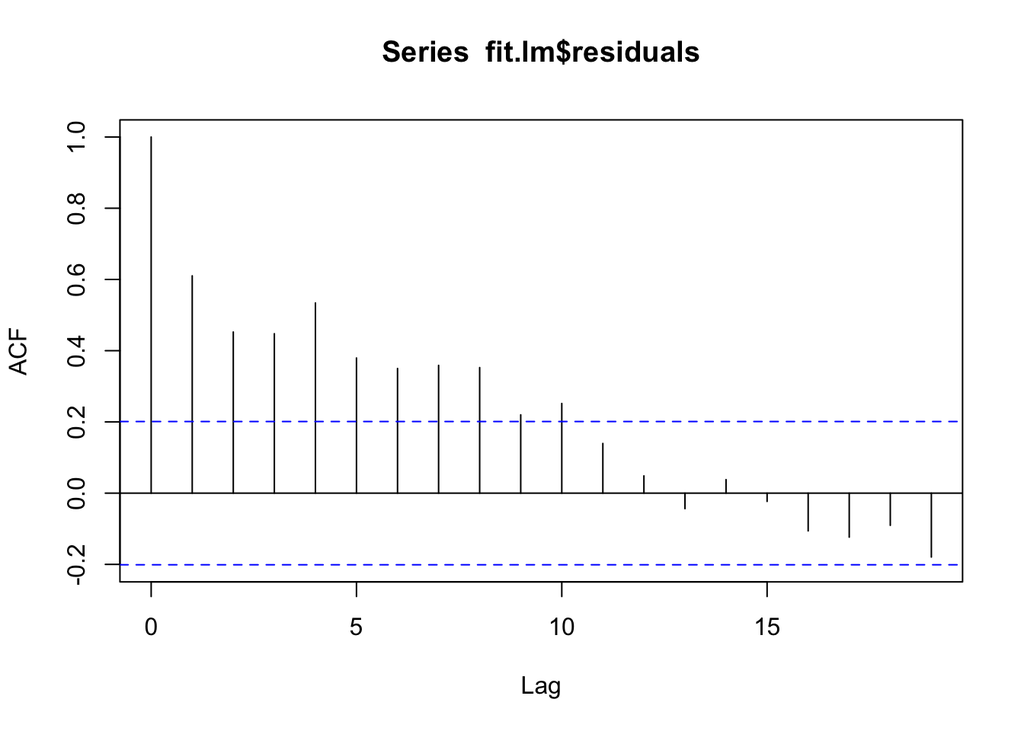

```r
## ACF图，可以看出，直到10阶延迟序列，都具有显著的自相关
acf(fit.lm$residuals)
```

```r
## 自相关性使用Durbin-Watson检验
## dwtest(fit.lm)

## granger causality
ndiffs(climate[, 1], test = "adf")
```

```
## [1] 1
```

```r
ndiffs(climate[, 2], test = "adf")
```

```
## [1] 1
```